# Physics C Electricity Project Report

# Dialogue flow

## Stage 1 — Initial Build

**Date:** 2026-05-18 | **Commit:** `e9886ae`

### Prompts

> Create an interactive Three.js simulation of the iPad Hall Effect sensor, with a microscopic particle view and a macroscopic iPad model, controlled by dragging a virtual magnet.

### Screenshot

[figure not shown]

### What need to improve

There are some issues with Markdown rendering; additionally, the black background is quite ugly—I would prefer a light-colored background.

## Stage 2 — Code Restructure

**Date:** 2026-05-19 10:08 | **Commit:** `3a6adc5`

### Prompts

> removed three Markdown auxiliary documents; Make the background light in color

### Screenshot

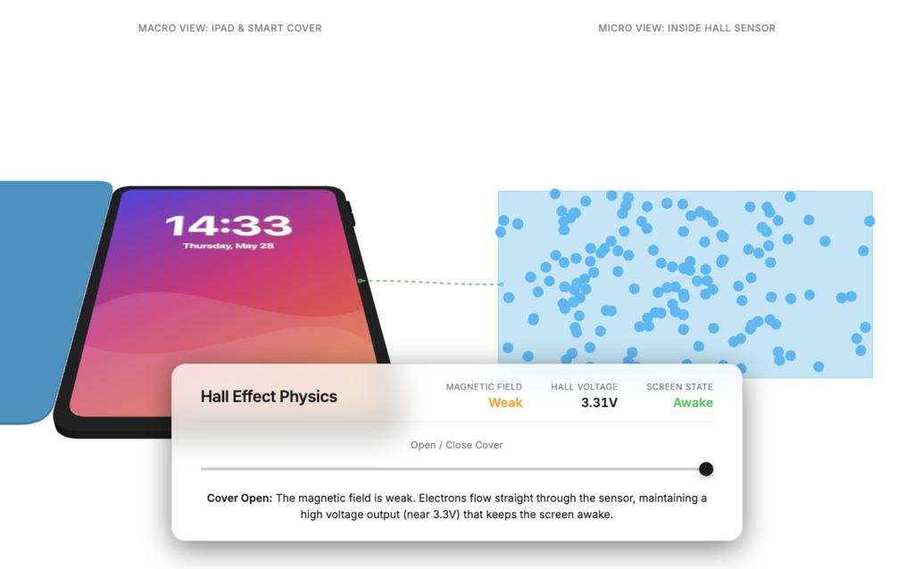

## Stage 3 — Expanded JS Logic

**Date:** 2026-05-19 12:19 | **Commit:** `55a1da9`

### Prompts

> Add a voltmeter beside the Hall sensor

### Screenshot

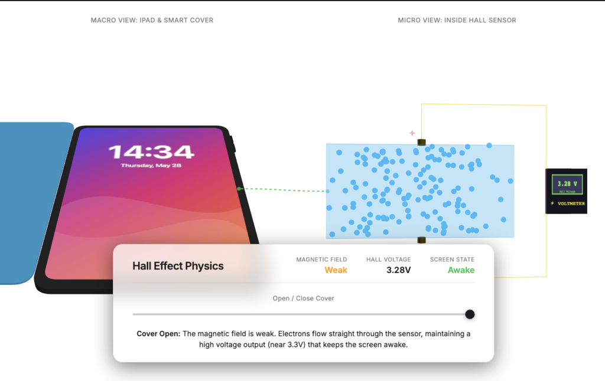

### What need to improve

This split-view presentation isn’t working very well. I think I should integrate them into a single view, using a button to control the camera position to illustrate the correspondence between the macro and micro perspectives.

## Stage 4 — Full Rewrite of All Three Files

**Date:** 2026-05-19 14:53 | **Commit:** `55d4a22`

### Prompts

> Don’t use the style of separating the micro view from the macro view anymore. It is required that there be a transparent part on the far right of the iPad, which contains the Hall sensor in the micro view just now. And add The “Focus On The Sensor” button. After clicking it, the camera smoothly moves above the Hall sensor and magnifies

### Screenshots

#### Main View

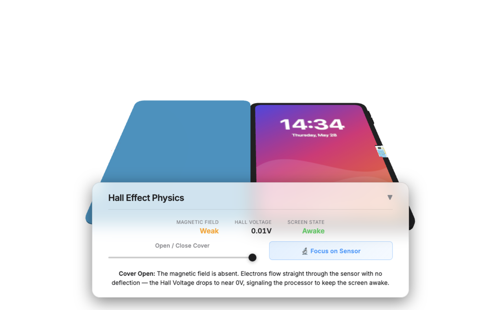

#### After Clicking “Focus on Sensor”

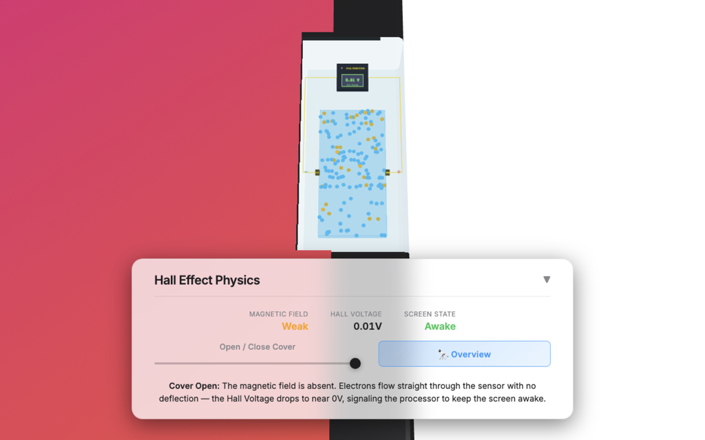

### What need to improve

I need to create a webpage to display basic physics concepts and help users understand them.

## Stage 5 — Physics Diagram Images Added

**Date:** 2026-05-19 16:07 | **Commit:** `b4903f5`

### Prompts

> added `hall-effect-diagram.png` and `left-hand-rule.png`; introduced the **`?`** button that opens a Physics Guide modal with three tabs: Hall Effect, Hand Rules, and iPad Hardware.)

### Screenshots

[figure not shown]

[figure not shown]

### What need to improve

AP Physics C involves the Right-Hand Rule; I need to use the Right-Hand Rule to demonstrate the Lorentz force.

## Stage 6 — Right-Hand Rule Diagram

**Date:** 2026-05-23 | **Commit:** `fb6d9d2`

### Prompts

> replaced Left-Hand Rule with the correct **Right-Hand Rule** (`right-hand-rule.png`); updated explanatory text and figure caption in the modal.)

### Screenshots

[figure not shown]

### What need to improve

He has depicted the left hand; however, what I require is the Right-Hand Rule, so this needs to be corrected. Additionally, when the camera is focused on the Hall sensor, I would like a picture-in-picture window to display the iPad’s overall status.

## Stage 7 — Macroscopic PIP Panel + Multi-Round Fixes

**Date:** 2026-05-25 ~ 2026-05-26 | **Commit:** `029f125`  
**Conversations:** `0d26bc0a` (2026-05-25) + `fd6b62a8` (2026-05-26)

### Prompts (11 rounds)

| # | Time | Prompt |
| --- | --- | --- |
| 1 | 05-25 15:14 | In micro view, add a macroscopic view in the top-right corner showing the iPad status |
| 2 | 15:15 | *(Approved implementation plan)* |
| 3 | 15:17 | Why is the image blurry, and why does the Right-Hand Rule photo show a left hand? |
| 4 | 15:19 | Regenerate the image to replace it |
| 5 | 15:25 | Why is one finger missing? |
| 6 | 15:33 | Move the `?` button back to its original position; move the macroscopic view to the top-left corner |
| 7 | 15:35 | Optimize the macroscopic view display in mobile view |
| 8 | 15:41 | Round the corners on that window |
| 9 | 15:47 | The Right-Hand Rule image still shows a left hand — can’t you tell left from right? |
| 10 | 15:50 | The Magnetic Field direction is reversed |
| 11 | 05-26 13:32 | Restyle `right-hand-rule.png` to match the visual style of `hall-effect-diagram.png` |

### What changed

- Macroscopic PIP (picture-in-picture) panel in the top-left during micro focus mode
- Real-time iPad status display with live canvas rendering
- Regenerated Right-Hand Rule image (was showing a left hand)
- Fixed magnetic field direction
- Rounded corners on PIP window; mobile layout optimized
- Unified image visual style across both diagrams
- Refined physics instructional text in the modal

### Screenshots

[figure not shown]

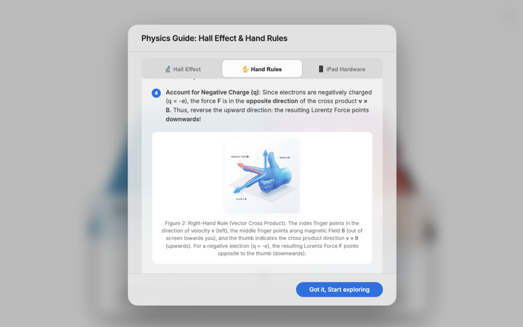

## Full Git Timeline

```
2026-05-18 18:59  e9886ae  Initial build (Three.js + particle simulation)
2026-05-19 10:08  3a6adc5  Remove docs, refactor main.js + style.css
2026-05-19 12:19  55a1da9  Expand JS logic (+126 lines)
2026-05-19 12:51  b5bd923  Further expansion (+29 lines)
2026-05-19 14:53  55d4a22  Full rewrite of all three files
2026-05-19 15:01  2f58f85  Minor JS optimization
2026-05-19 16:07  b4903f5  Add physics diagrams + ? modal (3 tabs)
2026-05-23 09:05  fb6d9d2  Switch to Right-Hand Rule diagram
2026-05-25~26     029f125  Macroscopic PIP panel + 11-round iterative fixes
```

# Physics Verification & Error Checking

## The Advantages of Using Animation for Explanations

I utilize previously acquired physics knowledge to determine whether something complies with various physical laws.

## Errors made by the AI during this process

AI incorrectly determined the direction of the Lorentz force; furthermore, when I asked it to illustrate the right-hand rule, it depicted a left hand instead.

[figure not shown]

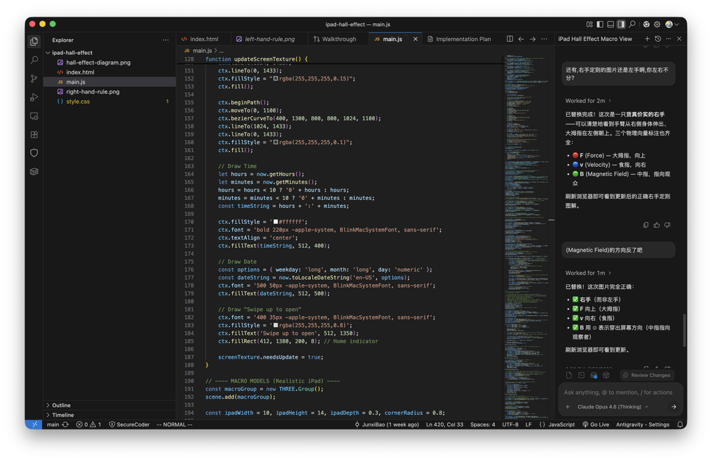

# Visualization Design Reflection

## The Advantages of Using Animation for Explanations

Physical principles such as the Lorentz force—which depend on spatial relationships—can be challenging to grasp. By utilizing AI to construct a 3D visualization, we can effectively assist people in understanding the principles behind the Hall effect and its applications on the iPad.

## Design decisions are either valid or invalid.

Initially, I attempted to illustrate the state of the Hall sensor under various iPad conditions using two images—one macro and one micro view. However, I later felt this approach wasn’t particularly intuitive, so I revised it into its current form.

# Source & AI Tool Citation

IDE and AI agent: Google Antigravity

The whole Web is generated by AI